# Extreme Value Theory

```r
library(rnoaa)
library(leaflet)
library(lawn)
options(noaakey = "piRauSeecCMaIVkleStduqdxoaLLOPMs")
lawn_bbox_polygon(c(113.338953078, -43.6345972634, 153.569469029, -10.6681857235)) %>% view
```

[interactive chart not shown]

```r
# List stations corresponding to Australia
all_stations<-ncdc_stations(extent = c(-43.6345972634, 113.338953078, -10.6681857235, 153.569469029))
head(all_stations)
```

```
## $meta
## $meta$totalCount
## [1] 17053
##
## $meta$pageCount
## [1] 25
##
## $meta$offset
## [1] 1
##
##
## $data
##    elevation    mindate    maxdate latitude                         name
## 1      295.0 1975-10-03 2007-10-08 -18.3000   GEORGETOWN POST OFFICE, AS
## 2        9.0 1948-01-01 2022-07-17 -16.2880            WILLIS ISLAND, AS
```

[output cut: 49 more lines]

# Get Australian Rainfall data

wrapper_get_meta_data function get all Australian station data from R package “rnoaa”.

```r
wrapper_get_meta_data <- function(country_id = "AS", network_id = "N"){

  ghcnd_meta_data = ghcnd_stations()
  as_meta_data = dplyr::filter(ghcnd_meta_data,
                               substr(id, 1, 2) == country_id & substr(id, 3, 3) == network_id)

  return(as_meta_data)

}
```

```r
as_meta_data = wrapper_get_meta_data()
save(as_meta_data, file = "Data/AS_meta_data.RData")
head(as_meta_data)
```

```
## # A tibble: 6 × 11
##   id          latit…¹ longi…² eleva…³ state name  gsn_f…⁴ wmo_id element first…⁵
##   <chr>         <dbl>   <dbl>   <dbl> <chr> <chr> <chr>   <chr>  <chr>     <int>
## 1 ASN00001000   -16.3    127.     320 ""    KARU… ""      ""     PRCP       1940
## 2 ASN00001000   -16.3    127.     320 ""    KARU… ""      ""     DAPR       1963
## 3 ASN00001000   -16.3    127.     320 ""    KARU… ""      ""     DWPR       1963
## 4 ASN00001000   -16.3    127.     320 ""    KARU… ""      ""     MDPR       1963
## 5 ASN00001001   -15.2    128.       2 ""    OOMB… ""      ""     PRCP       1914
## 6 ASN00001001   -15.2    128.       2 ""    OOMB… ""      ""     DAPR       1916
## # … with 1 more variable: last_year <int>, and abbreviated variable names
## #   ¹latitude, ²longitude, ³elevation, ⁴gsn_flag, ⁵first_year
## # ℹ Use `colnames()` to see all variable names
```

Above meta_data contains following precipitation_elements.\

- PRCP is the daily precipitation (**tenths of a mm**)
- MDPR is a multiday accumulated total (tenths of a mm)
- DAPR is the number of days in a multiday total
- DWPR number of days of non-zero rainfall in a multiday total.

Hence, we filter the PRCP only for further analysis.

```r
# Filtering pricipitation data
prcp_meta_data = dplyr::filter(as_meta_data, element == "PRCP")
head(prcp_meta_data)
```

```
## # A tibble: 6 × 11
##   id          latit…¹ longi…² eleva…³ state name  gsn_f…⁴ wmo_id element first…⁵
##   <chr>         <dbl>   <dbl>   <dbl> <chr> <chr> <chr>   <chr>  <chr>     <int>
## 1 ASN00001000   -16.3    127.   320   ""    KARU… ""      ""     PRCP       1940
## 2 ASN00001001   -15.2    128.     2   ""    OOMB… ""      ""     PRCP       1914
## 3 ASN00001003   -14.1    127.     5   ""    PAGO… ""      ""     PRCP       1909
## 4 ASN00001004   -15.4    125.    47   ""    KUNM… ""      ""     PRCP       1915
## 5 ASN00001005   -15.5    128.    20   ""    WYND… ""      ""     PRCP       1887
## 6 ASN00001006   -15.5    128.     3.8 ""    WYND… ""      "9521… PRCP       1951
## # … with 1 more variable: last_year <int>, and abbreviated variable names
## #   ¹latitude, ²longitude, ³elevation, ⁴gsn_flag, ⁵first_year
## # ℹ Use `colnames()` to see all variable names
```

From this data set, distribution of stations are visualized through map visualization to get an idea of spreading of rain gauges in Australia.

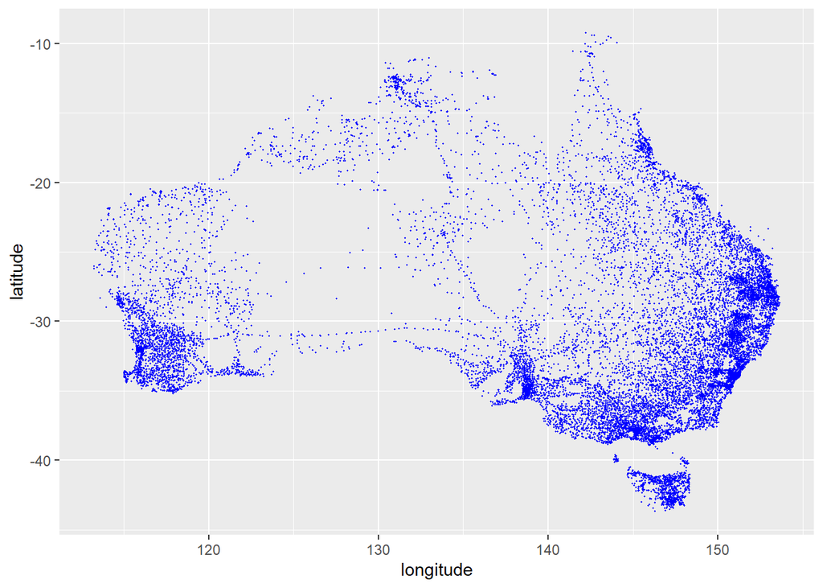

```r
library(ggplot2)
ggplot(prcp_meta_data, aes(x = longitude, y = latitude)) + geom_point(size = 0.2,col="blue")
```

I have selected eight sites to reflect the rainfall categories as follows:\

- Birdsville Police Station (38002) [Arid]
- Cambooya Post Office (41011) [Summer]
- Cape Naturaliste (9519) [Winter Dominant]
- Cataract Dam (68016) [Uniform]
- Eudunda (24511) [Winter]
- Gabo Island Lighthouse (84016) [Uniform]
- Oenpelli (14042) [Summer Dominant]
- Sorell (Whitlea) (94063) [Uniform]

```r
# function for obtaining precipitation data

Australian_prcp_data <- function(stn_ids){
  prcp_data <-meteo_pull_monitors(monitors=stn_ids)
  prcp_data <- select(prcp_data,c('id','date','prcp'))
  return(prcp_data)
}
```

```r
library(dplyr)
station_id="ASN00038002"
# Obtain the corresponding precipitation data
prcp_data_38002 <- Australian_prcp_data(station_id)
prcp_data_38002<-prcp_data_38002 %>% filter(date<="2022-06-04")
#head(prcp_data_38002)
station_id="ASN00041011"
# Obtain the corresponding precipitation data
prcp_data_41011 <- Australian_prcp_data(station_id)
#head(prcp_data_41011)
station_id="ASN00009519"
# Obtain the corresponding precipitation data
prcp_data_9519 <- Australian_prcp_data(station_id)
prcp_data_9519<-prcp_data_9519 %>% filter(date<="2022-07-07")
#head(prcp_data_9519)
station_id="ASN00068016"
# Obtain the corresponding precipitation data
prcp_data_68016 <- Australian_prcp_data(station_id)
#head(prcp_data_68016)
station_id="ASN00024511"
# Obtain the corresponding precipitation data
prcp_data_24511 <- Australian_prcp_data(station_id)
prcp_data_24511<-prcp_data_24511 %>% filter(date<="2022-07-07")
#head(prcp_data_24511)
station_id="ASN00084016"
# Obtain the corresponding precipitation data
prcp_data_84016 <- Australian_prcp_data(station_id)
prcp_data_84016<-prcp_data_84016 %>% filter(date<="2022-07-07")
#head(prcp_data_84016)
station_id="ASN00014042"
# Obtain the corresponding precipitation data
prcp_data_14042 <- Australian_prcp_data(station_id)
#head(prcp_data_14042)
station_id="ASN00094063"
# Obtain the corresponding precipitation data
prcp_data_94063 <- Australian_prcp_data(station_id)
#head(prcp_data_94063)
```

### Visualizing rainfall data

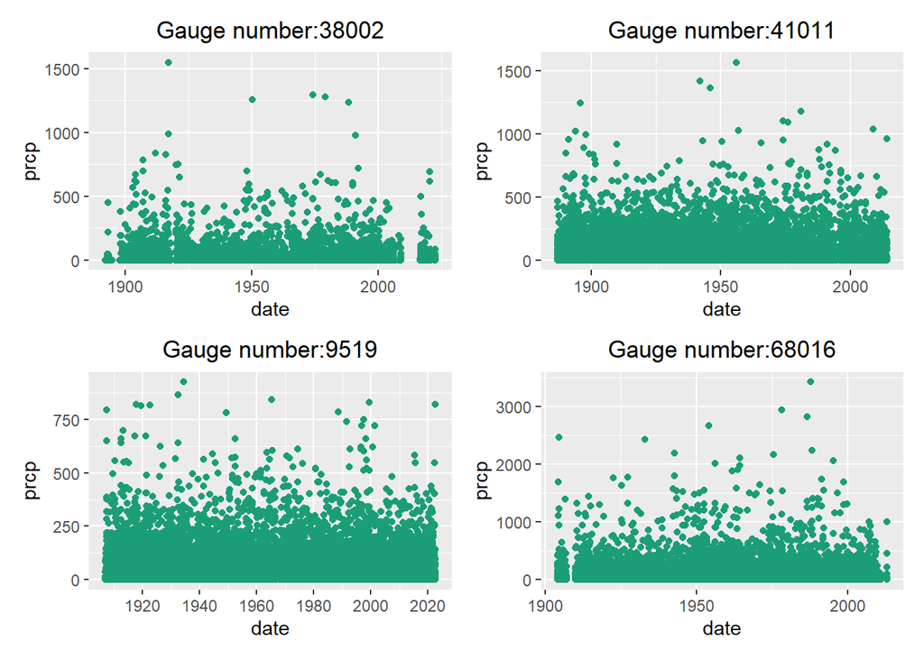

```r
a<-ggplot(prcp_data_38002, aes(x=date, y=prcp))+ geom_point(col="#1b9e77")+ggtitle("Gauge number:38002")+ theme(plot.title=element_text(hjust=0.5))

b<-ggplot(prcp_data_41011, aes(x=date, y=prcp))+ geom_point(col="#1b9e77")+ggtitle("Gauge number:41011")+ theme(plot.title=element_text(hjust=0.5))

c<-ggplot(prcp_data_9519, aes(x=date, y=prcp))+ geom_point(col="#1b9e77")+ggtitle("Gauge number:9519")+ theme(plot.title=element_text(hjust=0.5))

d<-ggplot(prcp_data_68016, aes(x=date, y=prcp))+ geom_point(col="#1b9e77")+ggtitle("Gauge number:68016")+ theme(plot.title=element_text(hjust=0.5))

e<-ggplot(prcp_data_24511, aes(x=date, y=prcp))+ geom_point(col="#1b9e77")+ggtitle("Gauge number:24511")+ theme(plot.title=element_text(hjust=0.5))

f<-ggplot(prcp_data_84016, aes(x=date, y=prcp))+ geom_point(col="#1b9e77")+ggtitle("Gauge number:84016")+ theme(plot.title=element_text(hjust=0.5))

g<-ggplot(prcp_data_14042, aes(x=date, y=prcp))+ geom_point(col="#1b9e77")+ggtitle("Gauge number:14042")+ theme(plot.title=element_text(hjust=0.5))

h<-ggplot(prcp_data_94063, aes(x=date, y=prcp))+ geom_point(col="#1b9e77")+ggtitle("Gauge number:94063")+ theme(plot.title=element_text(hjust=0.5))

library(patchwork)

plts1<-(a|b)/(c|d)
plts1
```

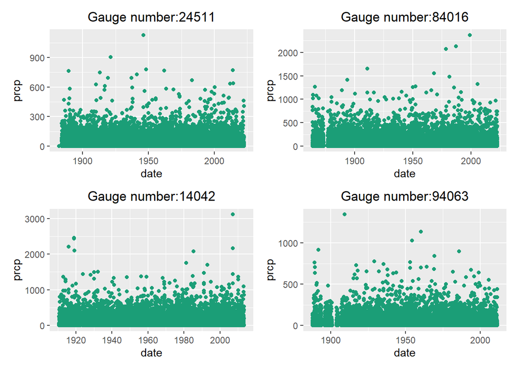

```r
plts2<-(e|f)/(g|h)
plts2
```

# **Block Maxima Approach - Generalized Extreme Value Distribution (GEV)**

```r
Annual_maximum_rainfall<-function(data){
 yr1= min(lubridate::year(data$date))
 yr2= max(lubridate::year(data$date))
 n=yr2-yr1+1
 annmax_prcp <- matrix(data = NA,nrow=n,ncol = 1)
 for (i in 1:n){
   yr = (yr1-1)+i
   index = which((lubridate::year(data$date)==yr))
   yr_wise_rainfall<-data[index,3]
   annmax_prcp[i,1] <- max(yr_wise_rainfall,na.rm = TRUE)
   #annmax_prcp[i,2] <- yr
 }
 return(annmax_prcp)
}
```

```r
Max_prcp_data_38002<-Annual_maximum_rainfall(prcp_data_38002)
Max_prcp_data_41011<-Annual_maximum_rainfall(prcp_data_41011)
Max_prcp_data_9519<-Annual_maximum_rainfall(prcp_data_9519)
Max_prcp_data_68016<-Annual_maximum_rainfall(prcp_data_68016)
Max_prcp_data_24511<-Annual_maximum_rainfall(prcp_data_24511)
Max_prcp_data_84016<-Annual_maximum_rainfall(prcp_data_84016)
Max_prcp_data_14042<-Annual_maximum_rainfall(prcp_data_14042)
Max_prcp_data_94063<-Annual_maximum_rainfall(prcp_data_94063)
```

#### Augmented Dickey-Fuller Test

- check whether maximum rainfall value series are stationary or not.

H0: The time series is regarded as non-stationary. H1: The time series is regarded as stationary.

```r
library(tseries)
adf.test(Max_prcp_data_38002[!is.infinite(rowSums(Max_prcp_data_38002)),])
```

```
##
##  Augmented Dickey-Fuller Test
##
## data:  Max_prcp_data_38002[!is.infinite(rowSums(Max_prcp_data_38002)),     ]
## Dickey-Fuller = -3.9599, Lag order = 4, p-value = 0.01363
## alternative hypothesis: stationary
```

```r
# 38002 max rainfall series is stationary by ADF test
adf.test(Max_prcp_data_41011)
```

```
##
##  Augmented Dickey-Fuller Test
##
## data:  Max_prcp_data_41011
## Dickey-Fuller = -3.0777, Lag order = 5, p-value = 0.1285
## alternative hypothesis: stationary
```

```r
# 41011 max rainfall series is not stationary
adf.test(Max_prcp_data_9519[!is.infinite(rowSums(Max_prcp_data_9519)),])
```

```
##
##  Augmented Dickey-Fuller Test
##
## data:  Max_prcp_data_9519[!is.infinite(rowSums(Max_prcp_data_9519)),     ]
## Dickey-Fuller = -4.3512, Lag order = 4, p-value = 0.01
## alternative hypothesis: stationary
```

```r
# 9519 max rainfall series is stationary by ADF test
adf.test(Max_prcp_data_68016[!is.infinite(rowSums(Max_prcp_data_68016)),])
```

```
##
##  Augmented Dickey-Fuller Test
##
## data:  Max_prcp_data_68016[!is.infinite(rowSums(Max_prcp_data_68016)),     ]
## Dickey-Fuller = -3.2105, Lag order = 4, p-value = 0.0898
## alternative hypothesis: stationary
```

```r
# 68016 max rainfall series is not stationary by ADF test
adf.test(Max_prcp_data_24511[!is.infinite(rowSums(Max_prcp_data_24511)),])
```

```
##
##  Augmented Dickey-Fuller Test
##
## data:  Max_prcp_data_24511[!is.infinite(rowSums(Max_prcp_data_24511)),     ]
## Dickey-Fuller = -5.3393, Lag order = 5, p-value = 0.01
## alternative hypothesis: stationary
```

```r
# 24511 max rainfall series is stationary by ADF test
adf.test(Max_prcp_data_84016[!is.infinite(rowSums(Max_prcp_data_84016)),])
```

```
##
##  Augmented Dickey-Fuller Test
##
## data:  Max_prcp_data_84016[!is.infinite(rowSums(Max_prcp_data_84016)),     ]
## Dickey-Fuller = -6.36, Lag order = 5, p-value = 0.01
## alternative hypothesis: stationary
```

```r
# 84016 max rainfall series is stationary by ADF test
adf.test(Max_prcp_data_14042)
```

```
##
##  Augmented Dickey-Fuller Test
##
## data:  Max_prcp_data_14042
## Dickey-Fuller = -4.0424, Lag order = 4, p-value = 0.01
## alternative hypothesis: stationary
```

```r
# 14042 max rainfall series is stationary by ADF test
adf.test(Max_prcp_data_94063[!is.infinite(rowSums(Max_prcp_data_94063)),])
```

```
##
##  Augmented Dickey-Fuller Test
##
## data:  Max_prcp_data_94063[!is.infinite(rowSums(Max_prcp_data_94063)),     ]
## Dickey-Fuller = -7.0776, Lag order = 4, p-value = 0.01
## alternative hypothesis: stationary
```

```r
# 94063 max rainfall series is stationary by ADF test
```

#### Plotting maximum value rainfall

- Best fit lines are indicated by black lines.

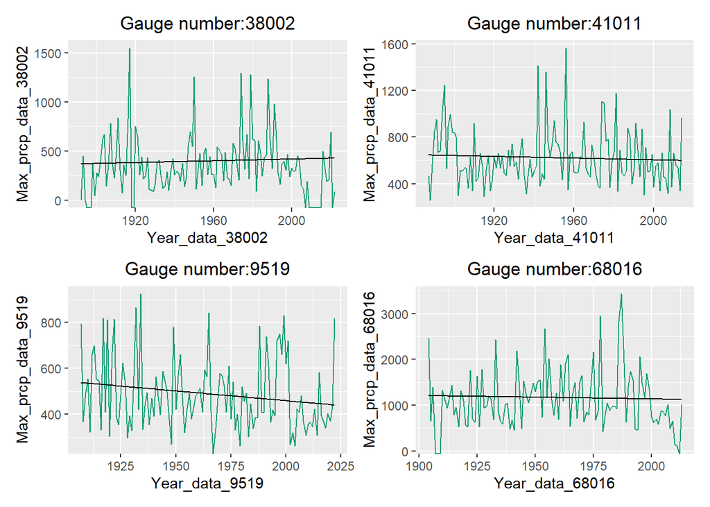

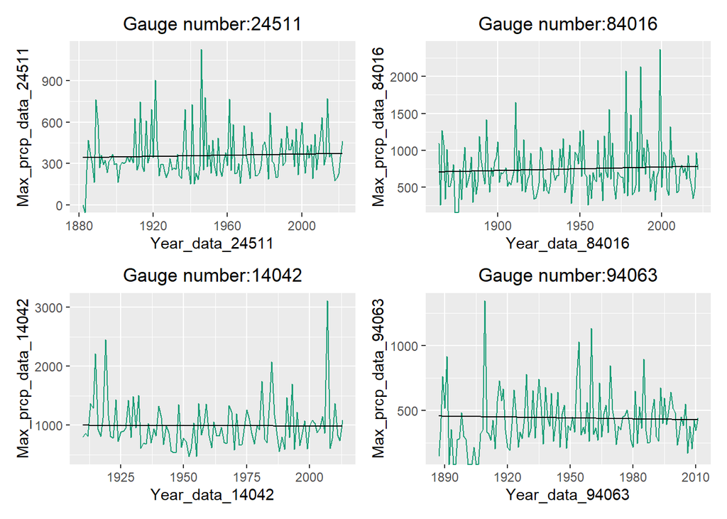

##### Block Maxima is usually modelled using the distribution from Generalized Extreme Value Families such as Gumbell, Weibull, and Frechet.

- CDFs are as follows:

$$F(x)=exp[\ -(1-\xi
\dfrac{x-\mu}{\sigma}) ]\; \hspace{0.5in} \xi \neq 0$$

$$F(x)=exp[\ -exp(-
\dfrac{x-\mu}{\sigma})]\ ; \hspace{0.5in} \xi =0$$

- location parameter - $\mu ; \hspace{0.1in} - \infty < \mu < \infty$
- scale parameter - $\sigma ; \hspace{0.1in} 0 < \sigma < \infty$
- shape parameter - $\xi \hspace{0.1in} - \infty < \xi < \infty$
- Gumbell distribution - $\xi=0$, Frechet distribution- $\xi >0$ , Weibull distribution - $\xi < 0$

$$Return
\hspace{0.1in}Period=\dfrac{1}{P(Exceedance)}=\dfrac{1}{P(Z>z)}=\dfrac{1}{1-F(z)}$$
The significance of the best non-stationary model, when compared to the stationary model, can be measured from the p-value of the Chi-square distribution.

- negative log-likelihood of stationary model -nlls
- best non-stationary model -nllns
- 2[nlls − nllns] ∼ χ2(df)

##### Case 1

$$X_{t} \sim GEV(\mu, \sigma,
\xi)$$

```r
library(ismev)
df<-Max_prcp_data_38002
df <- df[!is.infinite(rowSums(df)),]
A = gev.fit(df,ydat = NULL)
```

```
## $conv
## [1] 0
##
## $nllh
## [1] 801.2452
##
## $mle
## [1] 268.8849055 180.5163563   0.1297532
##
## $se
## [1] 18.89059690 14.45600726  0.07279384
```

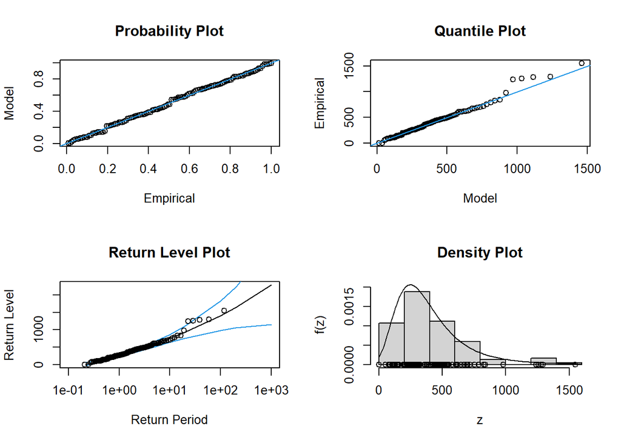

```r
gev.diag(A)
```

##### Case 2

$$X_{t} \sim GEV(\mu(t), \sigma,
\xi)$$
$$\mu(t)=\beta_{0}+\beta_{1}t$$

```r
library(ismev)
df<-df_max_rainfall__38002
time<-c(seq(1,length(df$Max_prcp_data_38002),1))
df<-cbind(df,time)
df <- df[!is.infinite(rowSums(df)),]
df1 <- as.matrix(df[,1])
df2 <- as.matrix(df[,2])
A = gev.fit(df1,ydat = df2,mul = 1)
```

```
## $model
## $model[[1]]
## [1] 1
##
## $model[[2]]
## NULL
##
## $model[[3]]
## NULL
##
##
## $link
## [1] "c(identity, identity, identity)"
##
## $conv
## [1] 0
##
## $nllh
## [1] 799.3186
##
## $mle
## [1] -1189.1658645     0.7441203   173.2827907     0.1716238
##
## $se
## [1] 691.70428763   0.35333601  14.55364005   0.08255357
```

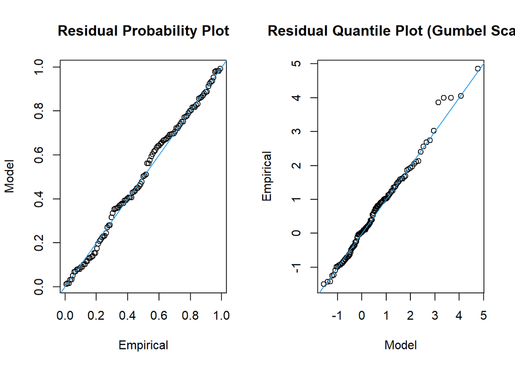

```r
gev.diag(A)
```

#### Significance of stationary and non-stationary GEV distribution model.

```r
# Upper tail critical value
qchisq(p=0.975, df=1, lower.tail=TRUE)
```

```
## [1] 5.023886
```

##### Case 3

$$X_{t} \sim GEV(\mu, \sigma(t),
\xi)$$
$$\sigma(t)=exp[\beta_{0}+\beta_{1}t]$$

```r
library(ismev)
df<-df_max_rainfall__38002
time<-c(seq(1,length(df$Max_prcp_data_38002),1))
df<-cbind(df,time)
df <- df[!is.infinite(rowSums(df)),]
df1 <- as.matrix(df[,1])
df2 <- as.matrix(df[,2])
A = gev.fit(df1,ydat = df2,sigl = 1, siglink = exp)
```

```
## $model
## $model[[1]]
## NULL
##
## $model[[2]]
## [1] 1
##
## $model[[3]]
## NULL
##
##
## $link
## [1] "c(identity, exp, identity)"
##
## $conv
## [1] 0
##
## $nllh
## [1] 1432.468
##
## $mle
## [1] 274.5708288 216.4859599  -0.1051594  -0.1076290
##
## $se
## [1]          NaN          NaN 2.000974e-06          NaN
```

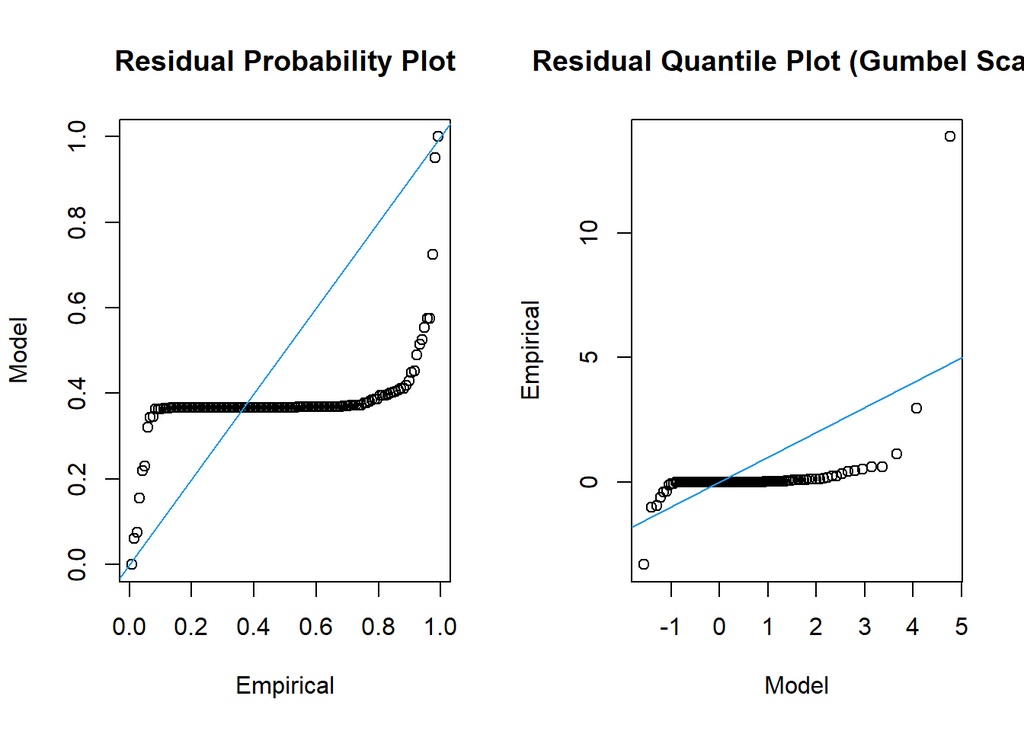

```r
gev.diag(A)
```

##### Case 4

$$X_{t} \sim GEV(\mu, \sigma(t),
\xi)$$
$$\mu(t)=\beta_{0}+\beta_{1}t$$
$$\sigma(t)=exp[\beta_{0}+\beta_{1}t]$$

```r
library(ismev)
df<-df_max_rainfall__38002
time<-c(seq(1,length(df$Max_prcp_data_38002),1))
df<-cbind(df,time)
df <- df[!is.infinite(rowSums(df)),]
df1 <- as.matrix(df[,1])
df2 <- as.matrix(df[,2])
A = gev.fit(df1,ydat = df2,mul=1, sigl = 1, siglink = exp)
```

```
## $model
## $model[[1]]
## [1] 1
##
## $model[[2]]
## [1] 1
##
## $model[[3]]
## NULL
##
##
## $link
## [1] "c(identity, exp, identity)"
##
## $conv
## [1] 0
##
## $nllh
## [1] 1174.568
##
## $mle
## [1] 273.8064470  -0.0927622 217.0186302  -0.1076623   0.5263092
##
## $se
## [1] 0.3168334187 0.0001615901 0.5301152505 0.0001616009 0.0821707756
```

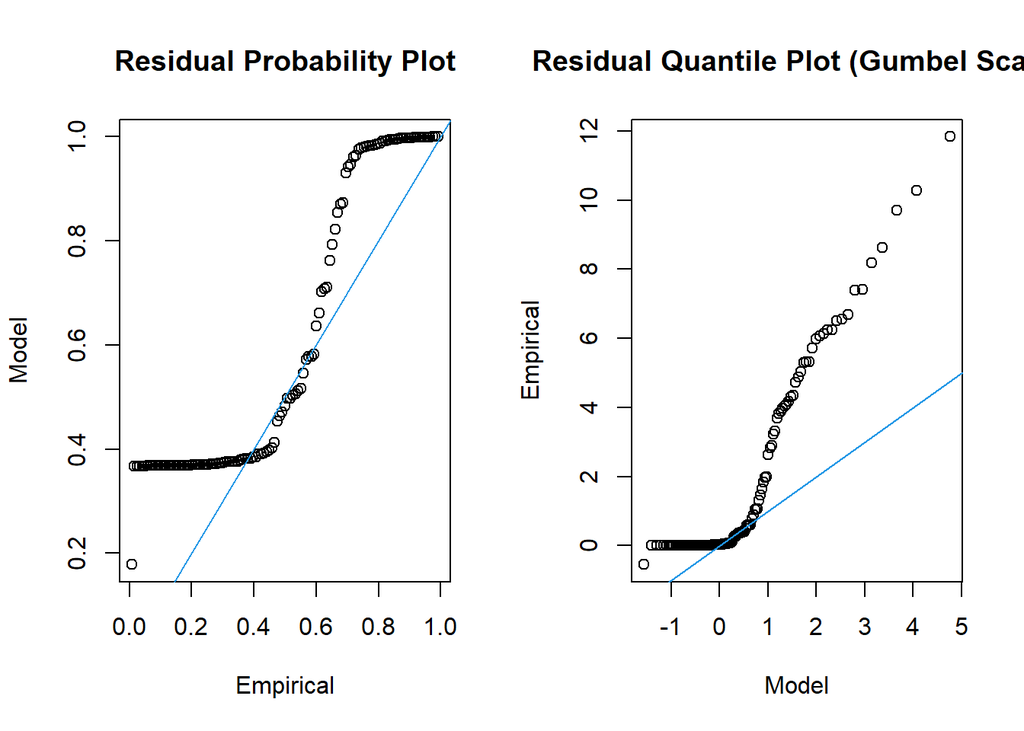

```r
gev.diag(A)
```

#### Gauge Number: 9519

##### Case 1

```r
df<-Max_prcp_data_9519
df <- df[!is.infinite(rowSums(df)),]
A = gev.fit(df,ydat = NULL)
```

```
## $conv
## [1] 0
##
## $nllh
## [1] 731.4295
##
## $mle
## [1] 411.793826 111.018608   0.118775
##
## $se
## [1] 12.11702644  9.40637335  0.09022892
```

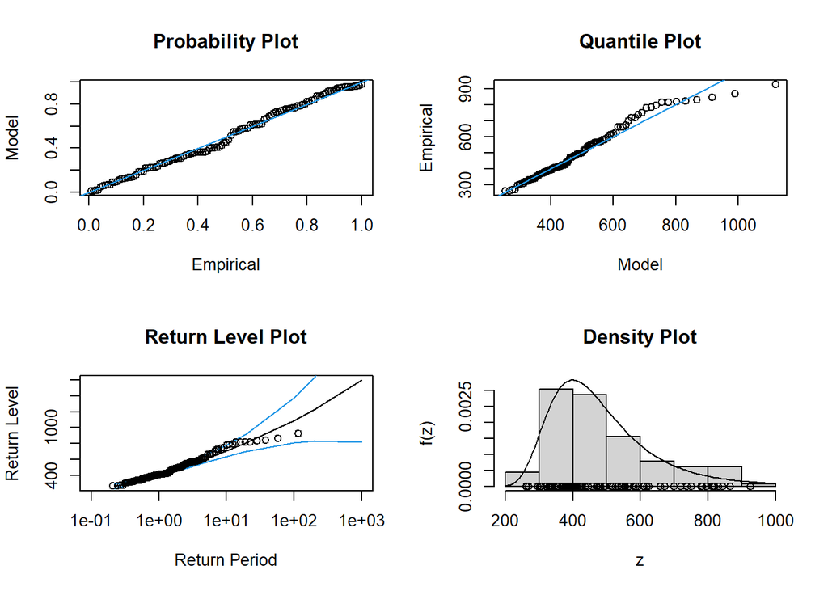

```r
gev.diag(A)
```

##### Case 2

```r
df<-df_max_rainfall__9519
time<-c(seq(1,length(df$Max_prcp_data_9519),1))
df<-cbind(df,time)
df <- df[!is.infinite(rowSums(df)),]
df1 <- as.matrix(df[,1])
df2 <- as.matrix(df[,2])
A = gev.fit(df1,ydat = df2,mul = 1)
```

```
## $model
## $model[[1]]
## [1] 1
##
## $model[[2]]
## NULL
##
## $model[[3]]
## NULL
##
##
## $link
## [1] "c(identity, identity, identity)"
##
## $conv
## [1] 0
##
## $nllh
## [1] 730.1713
##
## $mle
## [1] 1303.1621248   -0.4528139  110.6564553    0.1058330
##
## $se
## [1] 568.97416942   0.28886064   9.35773892   0.09076146
```

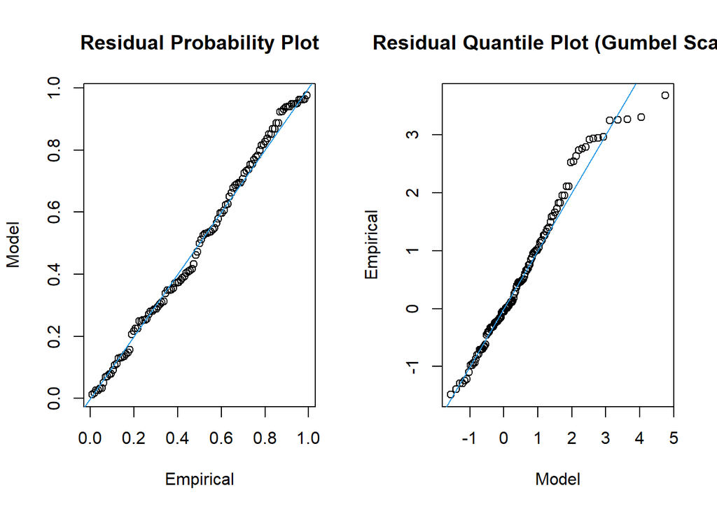

```r
gev.diag(A)
```

##### Case 3

```r
library(ismev)
df<-df_max_rainfall__9519
time<-c(seq(1,length(df$Max_prcp_data_9519),1))
df<-cbind(df,time)
df <- df[!is.infinite(rowSums(df)),]
df1 <- as.matrix(df[,1])
df2 <- as.matrix(df[,2])
A = gev.fit(df1,ydat = df2,sigl = 1, siglink = exp)
```

```
## $model
## $model[[1]]
## NULL
##
## $model[[2]]
## [1] 1
##
## $model[[3]]
## NULL
##
##
## $link
## [1] "c(identity, exp, identity)"
##
## $conv
## [1] 0
##
## $nllh
## [1] 742.1298
##
## $mle
## [1]  4.744395e+02  6.027244e+00 -5.513667e-04 -7.348396e-02
##
## $se
## [1] 1.820179e+01 9.054392e-02 2.000453e-06 1.055688e-01
```

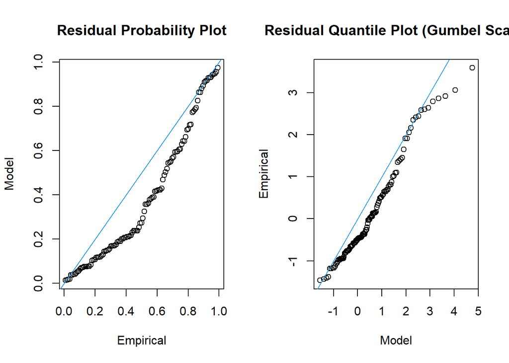

```r
gev.diag(A)
```

##### Case 4

```r
df<-df_max_rainfall__9519
time<-c(seq(1,length(df$Max_prcp_data_9519),1))
df<-cbind(df,time)
df <- df[!is.infinite(rowSums(df)),]
df1 <- as.matrix(df[,1])
df2 <- as.matrix(df[,2])
A = gev.fit(df1,ydat = df2,mul=1, sigl = 1, siglink = exp)
```

```
## $model
## $model[[1]]
## [1] 1
##
## $model[[2]]
## [1] 1
##
## $model[[3]]
## NULL
##
##
## $link
## [1] "c(identity, exp, identity)"
##
## $conv
## [1] 0
##
## $nllh
## [1] 886.9692
##
## $mle
## [1] 417.24278156  -0.07545047 122.08947483  -0.05994939   1.46214712
##
## $se
## [1] 1.607303e+00 2.000884e-06 2.803898e-01 2.000832e-06 2.423088e-01
```

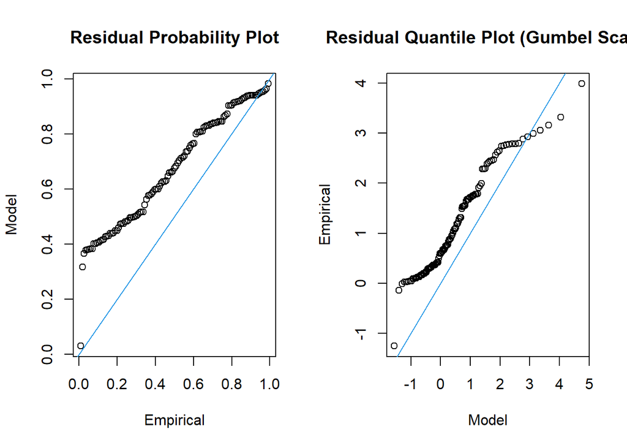

```r
gev.diag(A)
```

# **Peaks Over Threshold (POT) Approach - Generalized Pareto distribution (GPD)**

- Threshold value is decided based on 95th quantile

```r
# Quantile value finding
prcp_rank_data_38002<-sort(prcp_data_38002$prcp)
threshold_38002<-quantile(prcp_rank_data_38002, probs = 0.95)
threshold_38002
```

```
## 95%
##   8
```

#### Other ways to select threshold

- A mean residual life plot
- **Select the smallest threshold above which the mean excess plot is roughly linear.**

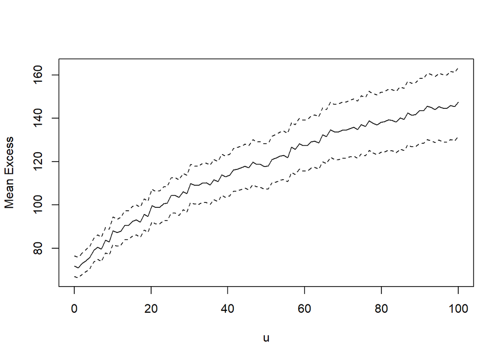

```r
data <- prcp_data_38002$prcp
data<- na.omit(data)
mrl.plot(data,umax = 100)
```

- **selecting the threshold is based on GPD parameters which are constant with U>Uo, where Uo is the threshold value.**

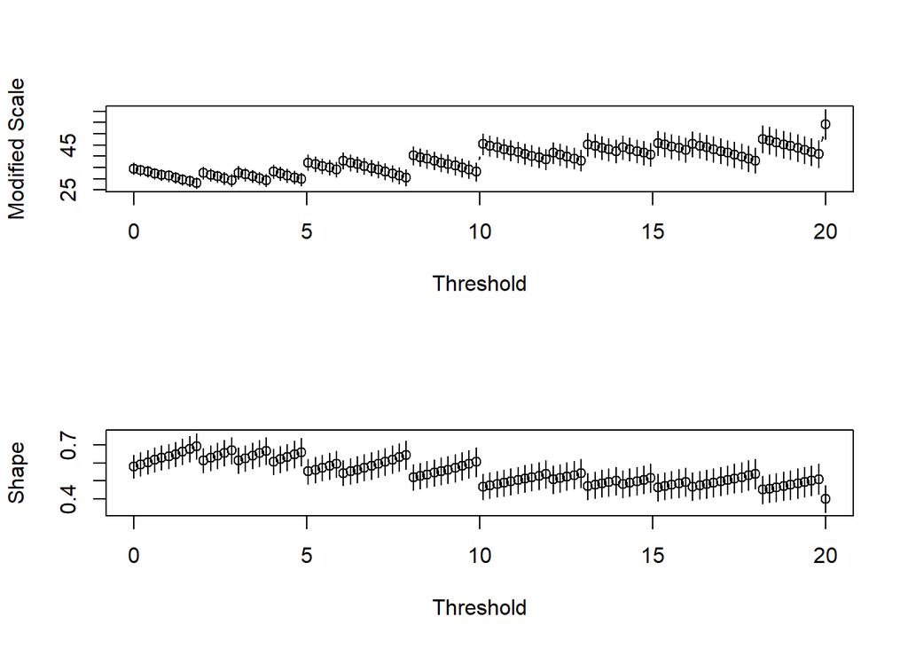

```r
data <- prcp_data_38002$prcp
data<- na.omit(data)
gpd.fitrange(data,0 , 20 , nint=100)
```

Therefore, rainfall values greater than “threshold_38002” is used to select extreme rainfall data.

```r
Extreme_rainfall_38002<-prcp_data_38002 %>% filter(prcp > threshold_38002)
```

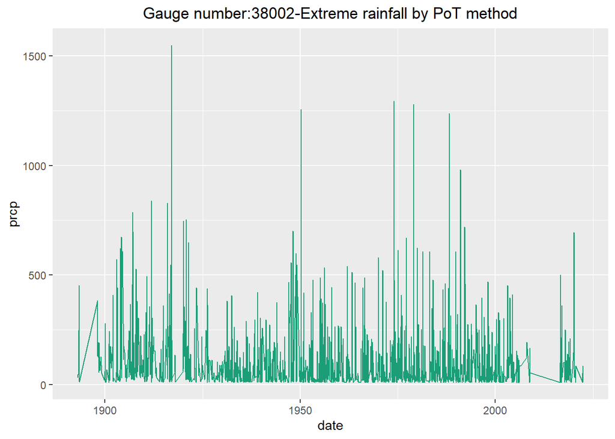

```r
ggplot(Extreme_rainfall_38002, aes(x=date, y=prcp))+ geom_line(col="#1b9e77")+ggtitle("Gauge number:38002-Extreme rainfall by PoT method")+ theme(plot.title=element_text(hjust=0.5))
```

Generalized Pareto Distribution modeling

##### Case 1

$$X_{t} \sim GPD(\sigma, \xi)$$

```r
df<-prcp_data_38002
df<-df[,c(2,3)]
df$date<-lubridate::year(df$date)
df <- na.omit(df)
B = gpd.fit(df$prcp,threshold = 8)
```

```
## $threshold
## [1] 8
##
## $nexc
## [1] 1981
##
## $conv
## [1] 0
##
## $nllh
## [1] 10528.76
##
## $mle
## [1] 44.697475  0.514717
##
## $rate
## [1] 0.04828057
##
## $se
## [1] 1.84282121 0.03645654
```

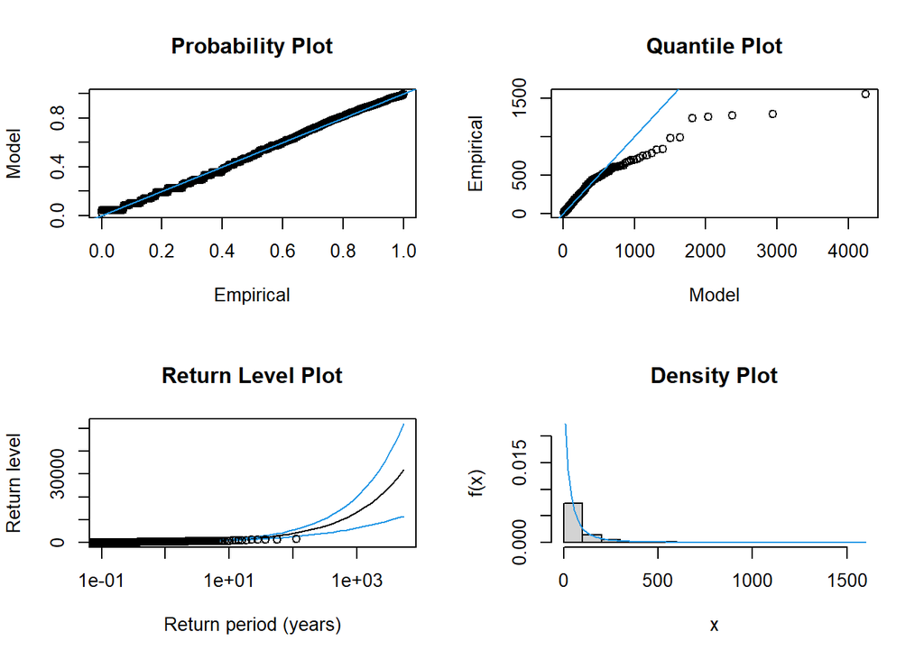

```r
gpd.diag(B)
```

##### Case 2

$$X_{t} \sim GPD(\sigma(t), \xi)$$
$$\sigma(t)=exp[\beta_{0}+\beta_{1}t]$$

```r
df<-prcp_data_38002
df<-df[,c(2,3)]
df$date<-lubridate::year(df$date)
df <- na.omit(df)
df1<- as.matrix(df$date)
B = gpd.fit(df$prcp,threshold = 8,ydat = df1,sigl = 1, siglink = exp)
```

```
## $model
## $model[[1]]
## [1] 1
##
## $model[[2]]
## NULL
##
##
## $link
## [1] "c(exp, identity)"
##
## $threshold
## [1] 8
##
## $nexc
## [1] 1981
##
## $conv
## [1] 0
##
## $nllh
## [1] 11241.5
##
## $mle
## [1] 103.59449812  -0.05120226   1.45004709
##
## $rate
## [1] 0.04828057
##
## $se
## [1] NaN NaN NaN
```

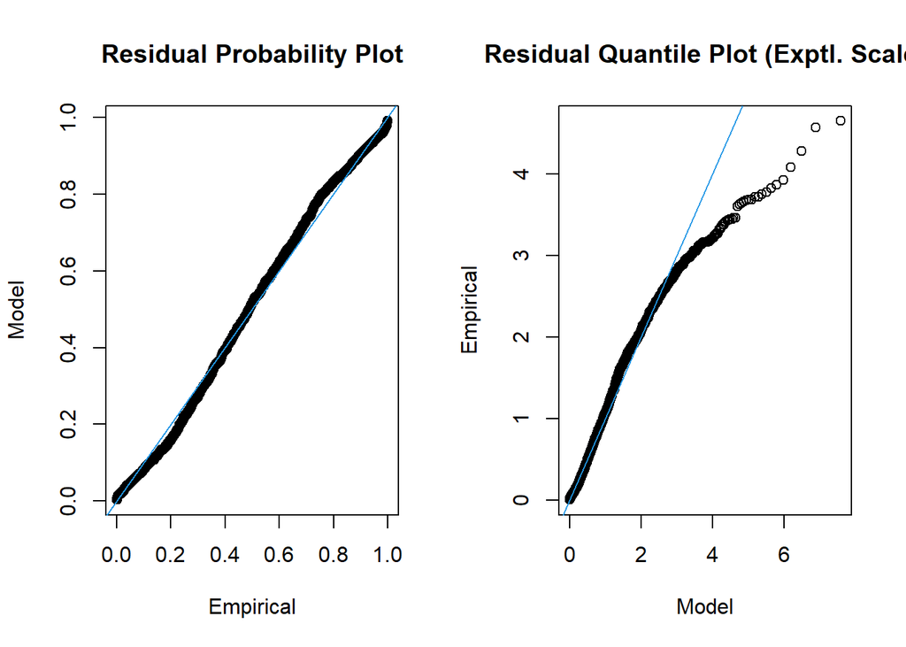

```r
gpd.diag(B)
```

##### Case 3

$$X_{t} \sim GPD(\sigma(t), \xi
(t))$$

$$\sigma(t)=exp[\beta_{0}+\beta_{1}t]$$

$$\xi(t)=\beta_{0}+\beta_{1}t$$

```r
df<-prcp_data_38002
df<-df[,c(2,3)]
df$date<-lubridate::year(df$date)
df <- na.omit(df)
df1<- as.matrix(df$date)
B = gpd.fit(df$prcp,threshold = 8,ydat = df1,sigl = 1, siglink = exp, shl = 1)
```

```
## $model
## $model[[1]]
## [1] 1
##
## $model[[2]]
## [1] 1
##
##
## $link
## [1] "c(exp, identity)"
##
## $threshold
## [1] 8
##
## $nexc
## [1] 1981
##
## $conv
## [1] 0
##
## $nllh
## [1] 10669.88
##
## $mle
## [1]  9.834247282 -0.003168819 35.683734977 -0.017623609
##
## $rate
## [1] 0.04828057
##
## $se
## [1]          NaN          NaN          NaN 2.009832e-06
```

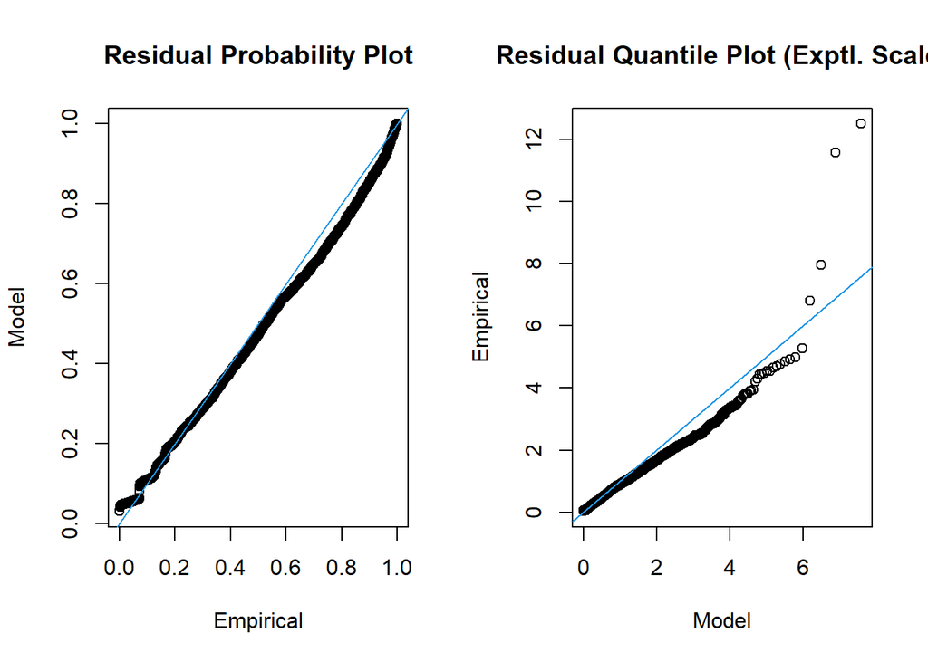

```r
gpd.diag(B)
```